# Curse of dimensionality

Harsha Achyuthuni

20/03/2020

## Multi dimension intuition

Because we are all used to two or three dimensions, we are not used to multidimensional thinking. In this blog, I want to show the curse of dimensionality using an example.

Take a classification problem, for example. In a classification problem, the goal is to define a distinct boundary between the classes. The probability of a data point to be of a particular class increases as it is farther away from the decision boundary.

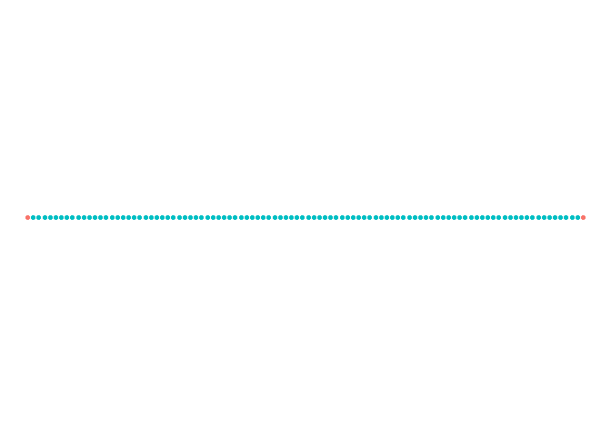

[figure not shown]

similarly, in an n-dimensional space, the probability would be:
$$p = 1 - 0.998^n$$
As ‘n’ increases, the probability of a data point is on the edges (defined by <0.001 from the border) is:

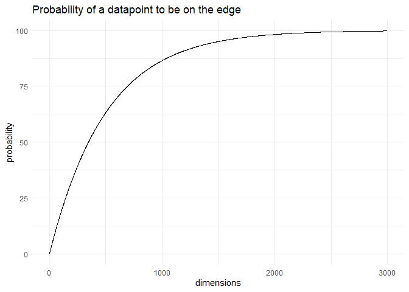

For just 50 dimensions, almost 10% of the data is on the edges. At 3000 dimensions, almost 99.75% of the data is on the edges.

In problems with a large number of features, a very high proportion of the data would be at the edges. This is called the curse of dimensionality and is the reason why feature engineering is essential.

References:  
1. [Hands-On Machine Learning with Scikit-Learn, Keras, and TensorFlow - Aurélien Géron](https://www.oreilly.com/library/view/hands-on-machine-learning/9781492032632/)